# HSC Survey Results

# Scots Bay Survey # 1 Results from 06/05/2025

## Survey Details

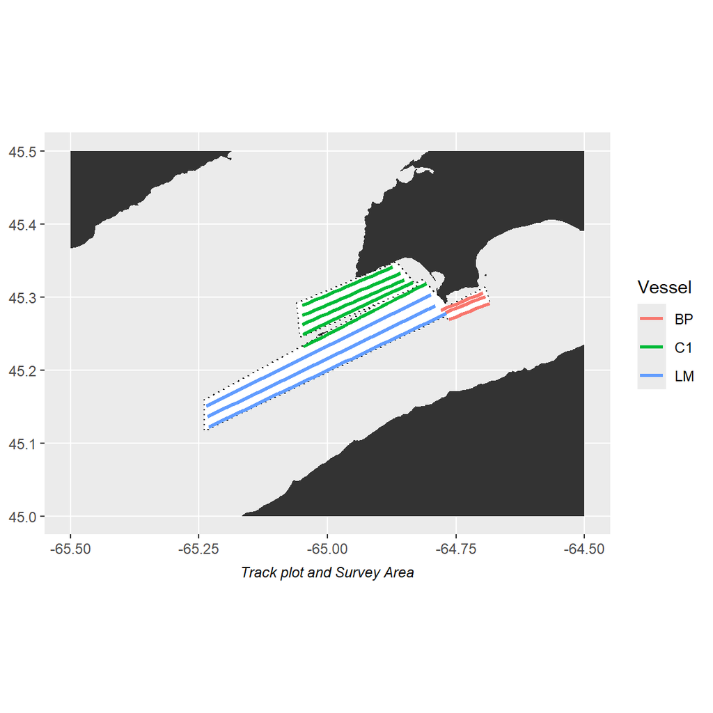

The Brunswick Provider ran 3 lines in the Eastern Survey Box, the Canada 100 ran one line in the Main Survey Box and 4 lines in the Northern Survey Box, and the Lady Melissa ran 3 lines in the Main Survey Box..

There was no plankton tow or CTD cast conducted.

No tags were applied during this survey.

Samples were obtained for target strength estimation.

### Tides Tables

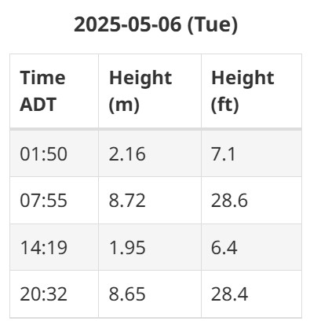

[figure not shown]

Tide Schedule for Margaretsville NS, Station #315m Source: www.waterlevels.gc.ca

### Acoustic Equipment

Each vessel was equipped with a Simrad ES38-18/200-18C combi (2-in-1) transducer prior to the survey that contains a 38kHz split beam and 200 kHz single beam transducer. Data was logged to the computer hard-drive for post-processing. All participating boats were calibrated on 38kHz before the survey.

## Survey Results

### Main Results

The results are subject to change as DFO will re-evaluate data editing, area estimation and apply a target strength.

**Preliminary biomass prediction for Scots Bay using standardized parallel transects is 12,306mt.**

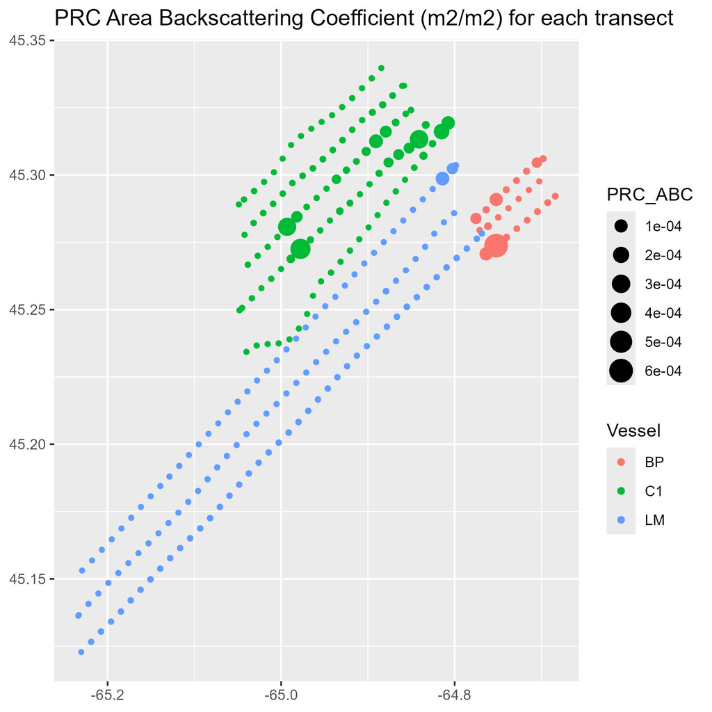

### Transect Details

Table 1: Transect Details

| Vessel | Transect # | Date/Time Start | Date/Time End | Start Lon | Start Lat | End Lon | End Lat | id | Y | X | Yend | Xend | Location | Distance (km) | Speed |
| --- | --- | --- | --- | --- | --- | --- | --- | --- | --- | --- | --- | --- | --- | --- | --- |
| BP | T01 | 2025-05-06 21:36:05 | 2025-05-06 22:05:06 | -64.764 | 45.270 | -64.684 | 45.292 | NA | NA | NA | NA | NA | SB | 6.84 | 7.63 |
| BP | T02 | 2025-05-06 22:10:07 | 2025-05-06 22:34:13 | -64.693 | 45.302 | -64.771 | 45.279 | NA | NA | NA | NA | NA | SB | 6.65 | 8.94 |
| BP | T03 | 2025-05-06 22:56:58 | 2025-05-06 23:32:23 | -64.779 | 45.283 | -64.698 | 45.306 | NA | NA | NA | NA | NA | SB | 6.94 | 6.35 |
| C1 | T01 | 2025-05-06 20:40:17 | 2025-05-06 22:09:58 | -65.047 | 45.233 | -64.807 | 45.319 | NA | NA | NA | NA | NA | SB | 22.29 | 8.05 |
| C1 | T02 | 2025-05-06 22:34:39 | 2025-05-06 23:33:47 | -64.874 | 45.342 | -65.049 | 45.289 | NA | NA | NA | NA | NA | SB | 15.41 | 8.44 |
| C1 | T03 | 2025-05-06 23:40:48 | 2025-05-07 00:45:16 | -65.049 | 45.275 | -64.858 | 45.333 | NA | NA | NA | NA | NA | SB | 16.80 | 8.44 |
| C1 | T04 | 2025-05-07 00:54:49 | 2025-05-07 02:11:57 | -64.834 | 45.321 | -65.048 | 45.250 | NA | NA | NA | NA | NA | SB | 19.57 | 8.22 |
| C1 | T05 | 2025-05-07 02:17:59 | 2025-05-07 03:25:00 | -65.049 | 45.263 | -64.850 | 45.324 | NA | NA | NA | NA | NA | SB | 17.46 | 8.44 |
| LM | T03 | 2025-05-07 00:07:00 | 2025-05-07 02:44:31 | -65.231 | 45.123 | -64.769 | 45.278 | NA | NA | NA | NA | NA | SB | 40.57 | 8.34 |
| LM | T02 | 2025-05-06 21:34:06 | 2025-05-06 23:59:57 | -64.791 | 45.289 | -65.234 | 45.136 | NA | NA | NA | NA | NA | SB | 38.89 | 8.64 |
| LM | T01 | 2025-05-06 18:43:28 | 2025-05-06 21:27:02 | -65.237 | 45.151 | -64.799 | 45.304 | NA | NA | NA | NA | NA | SB | 38.94 | 7.71 |

### Survey Summary

Table 2: Acoustic Survey Results

| Vessel | Transect No. | Target Strength (db/kg) | Mean Sa (/m2) | Biomass Density (kg/m2) |
| --- | --- | --- | --- | --- |
| BP | T01 | -35.5 | -39.628 | 0.387 |
| C1 | T04 | -35.5 | -43.411 | 0.162 |
| C1 | T05 | -35.5 | -44.641 | 0.122 |
| BP | T03 | -35.5 | -45.409 | 0.102 |
| C1 | T01 | -35.5 | -48.465 | 0.051 |
| LM | T01 | -35.5 | -53.563 | 0.016 |
| BP | T02 | -35.5 | -58.382 | 0.005 |
| C1 | T03 | -35.5 | -58.905 | 0.005 |
| LM | T03 | -35.5 | -61.693 | 0.002 |
| C1 | T02 | -35.5 | -65.214 | 0.001 |
| LM | T02 | -35.5 | -66.468 | 0.001 |

Note:  
Transects are listed from greatest to least backscatter.

Table 3: Survey Summary Table

| Layer | Target Strength | Area (km2) | Mean Sa | Density (kg/m2) | Biomass (tons) | Percent Area | Percent Biomass | Standard Error (tons) | Standard Error (%) |
| --- | --- | --- | --- | --- | --- | --- | --- | --- | --- |
| Main Box | -35.5 | 214.70690 | -54.2811 | 0.0173 | 2,842.707 | 67.5 | 23.1 | 2,479.67 | 87.23 |
| Northern Box | -35.5 | 87.27066 | -46.5900 | 0.0723 | 6,789.990 | 27.4 | 55.2 | 3,573.67 | 52.63 |
| Eastern Box | -35.5 | 16.13292 | -43.3066 | 0.1646 | 2,673.328 | 5.1 | 21.7 | 1,846.56 | 69.07 |

### Greatest Biomass Densities

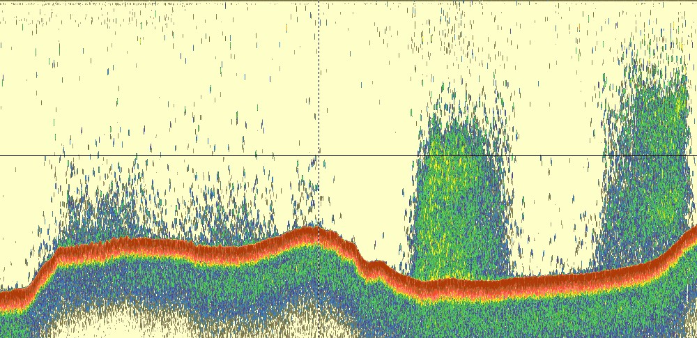

A snip from the transect with the greatest biomass density (kg/m2)

The single point with the largest biomass density (kg/m2) was recorded by **BP**, at the following location:

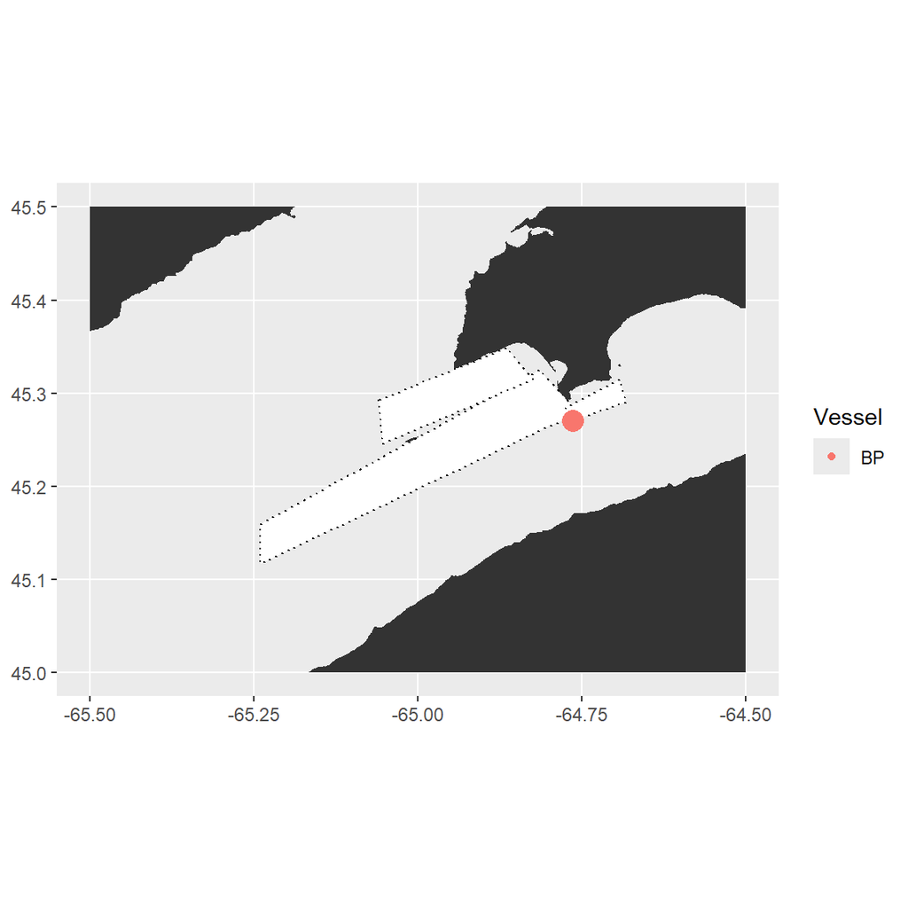

The transect with the greatest average biomass density (kg/m2) was recorded by **BP**, at the following location:

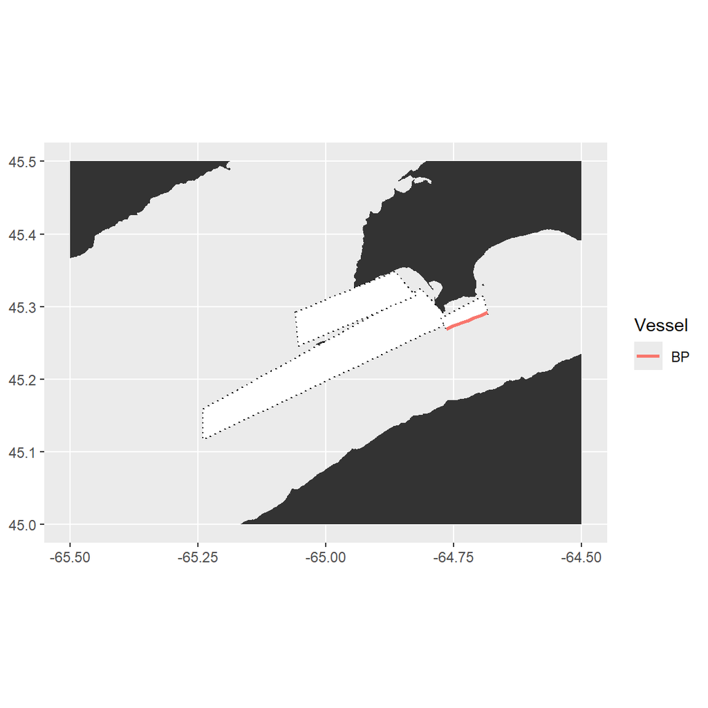

### Annual Summaries

This table does not include the biomass from adhoc surveys.

Table 4: Annual Comparison Table

| Ground | Survey Number | Current Year Survey Date | Current Year HSC Estimate | Current Year HSC Turnover Adjusted | Previous Year Survey Date | Previous Year HSC Estimate | Previous Year HSC Turnover Adjusted | Previous Year DFO Estimate | Previous Year DFO Turnover Adjusted |
| --- | --- | --- | --- | --- | --- | --- | --- | --- | --- |
| Scots Bay | 1 | 2025-05-06 | 12,306 | NA | 2024-05-05 | 78,662 | 78,662 | NA | NA |
| Scots Bay | 2 | 2025-05-21 | 120,045 | 118,023 | 2024-05-20 | 29,842 | 17,255 | NA | NA |
| Scots Bay | 3 | 2025-06-03 | 123,037 | 109,821 | 2024-06-02 | 93,804 | 89,523 | NA | NA |
| Scots Bay | 4 | NA | NA | NA | 2024-06-16 | 33,347 | 22,278 | NA | NA |
| Scots Bay | 5 | NA | NA | NA | 2024-07-01 | 7,252 | 3,123 | NA | NA |
| Scots Bay | 6 | NA | NA | NA | 2024-07-15 | 4,539 | 3,560 | NA | NA |
| Scots Bay | 7 | NA | NA | NA | 2024-07-29 | 32,655 | 32,016 | NA | NA |
| Scots Bay | 8 | NA | NA | NA | 2024-08-11 | 15,213 | 10,296 | NA | NA |
| Scots Bay | 9 | NA | NA | NA | 2024-08-25 | 9,206 | 6,810 | NA | NA |
| Scots Bay | 10 | NA | NA | NA | 2024-09-08 | 13,418 | 12,121 | NA | NA |
| Scots Bay | 11 | NA | NA | NA | 2024-09-23 | 8,735 | 7,098 | NA | NA |

Table 5: Annual Summary Table

| Year | Ground | HSC Estimate | HSC Turnover Adjusted | DFO Estimate | DFO Turnover Adjusted |
| --- | --- | --- | --- | --- | --- |
| 2024 | Scots Bay | 326,673 | 282,742 | NA | NA |
| 2025 | Scots Bay | 255,388 | 227,844 | NA | NA |

## Tagging, Plankton, and CTD Data

### Summary map

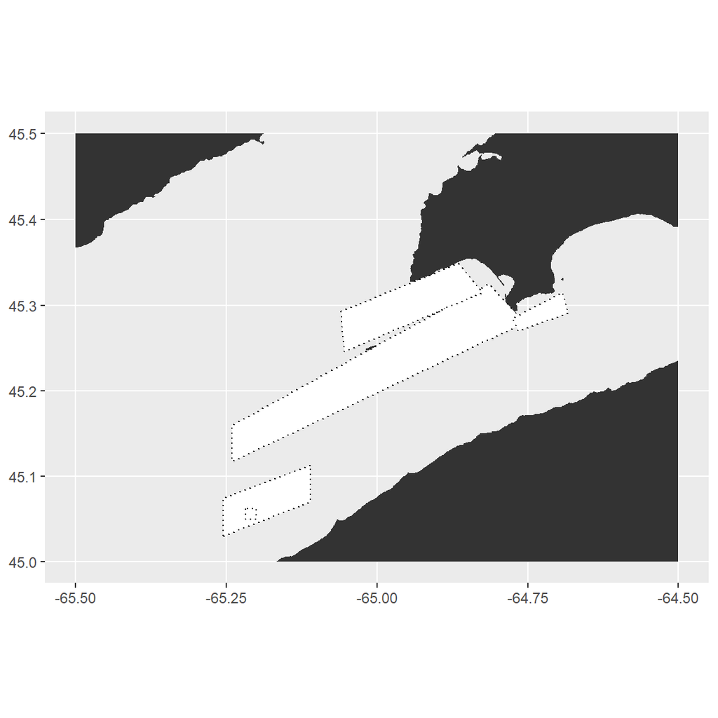

| Vessel | Tags |
| --- | --- |

### Plankton Data

#### Tow Summary Table

|  | Tow 1 | Tow 2 |
| --- | --- | --- |
| **Base Details** |  |  |
| Vessel | NA | NA |
| Set Number | NA | NA |
| Ground | SB | SB |
| Date | 06/05/2025 | 06/05/2025 |
| Wind Direction (km/h) | NA | NA |
| Swell (m) | NA | NA |
| Air Temp (c) | NA | NA |
| **Tow Details** |  |  |
| Tow Start | NA | NA |
| Tow End | NA | NA |
| Start Lat | NA | NA |
| End Lat | NA | NA |
| Start Lon | NA | NA |
| End Lon | NA | NA |
| Avg Tow Depth (m) | NA | NA |
| Speed | NA | NA |
| Heading | NA | NA |
| Tide Direction | NA | NA |
| **Other Data Collection** |  |  |
| Flow Start | NA | NA |
| Flow End | NA | NA |
| No. Revolutions | NA | NA |
| Distance (m) | NA | NA |
| Volume | NA | NA |
| Secchi Disappear (m) | NA | NA |
| Secchi Reappear (m) | NA | NA |

#### Tow Depth Profiles

[figure not shown]

Plankton tow depth profile #1

[figure not shown]

Plankton tow depth profile #2

### CTD Data

[figure not shown]

CTD depth profiles for all 2025 Scots Bay surveys so far.

#### Sea surface temperatures

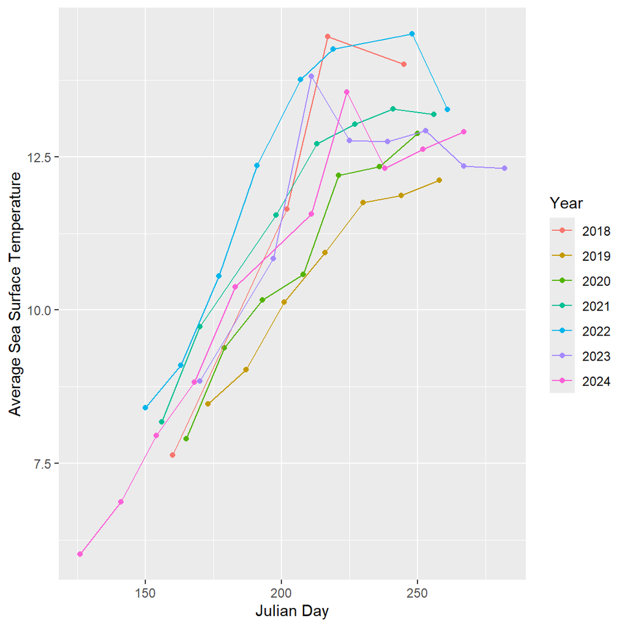

Annual average sea surface temperatures (SST) for Scots Bay.

## Vessel Performance

### Speed

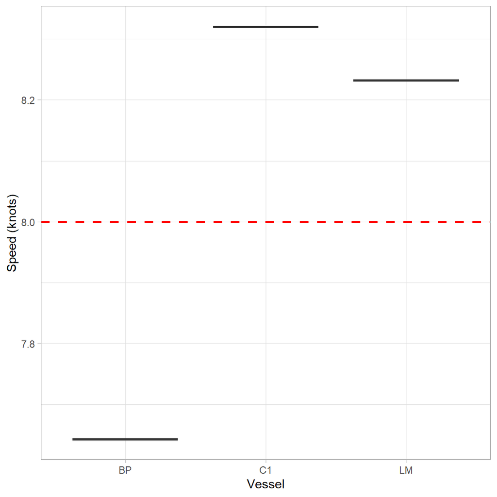

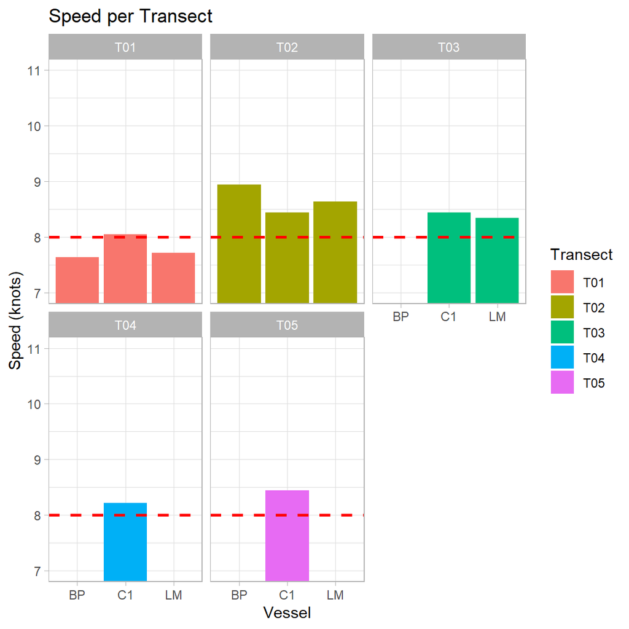

Average vessel speed was 8.06. This is above the 8 knot requirement; vessels are urged to slow down to prevent backscatter noise from interfering with the acoustic data.

The speed for each transect are rudimentary and are calculated based on distance. If a significant amount of distance is cut, the speed will appear slower.

### Distance

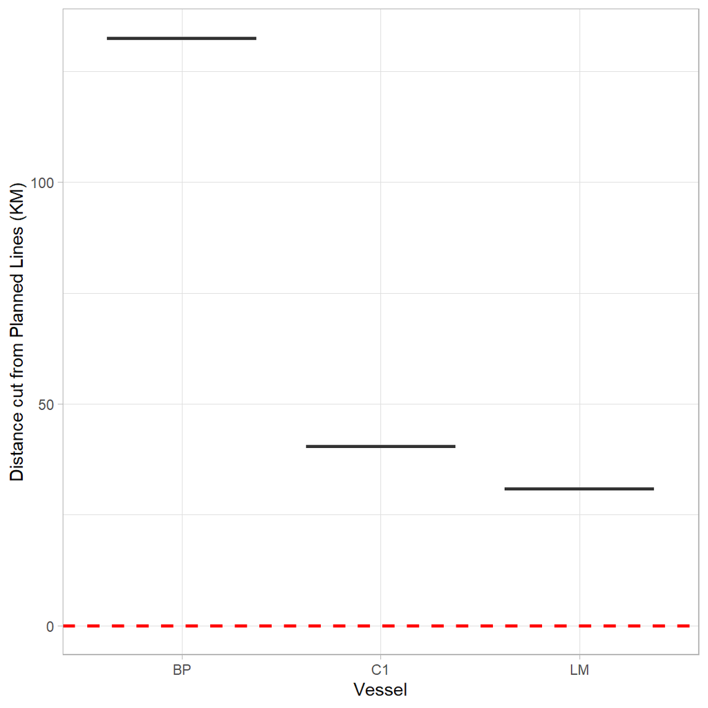

More than 2km of distance was cut from the planned lines; vessels are reminded to complete their assigned lines straight and without deviating or cutting corners short.